# Risk Factor Analysis

## Outcome Variable

**Outcome Variable:** ever_wasted

## Predictor Variables

**Intervention Variable:** nchldlt5

**Adjustment Set:**

unadjusted

## Stratifying Variables

The analysis was stratified on these variable(s):

- agecat
- studyid
- country

## Data Summary

| agecat | studyid | country | nchldlt5 | ever_wasted | n_cell | n |
| --- | --- | --- | --- | --- | --- | --- |
| 0-24 months | iLiNS-Zinc | BURKINA FASO | 1 | 0 | 838 | 3189 |
| 0-24 months | iLiNS-Zinc | BURKINA FASO | 1 | 1 | 235 | 3189 |
| 0-24 months | iLiNS-Zinc | BURKINA FASO | 2+ | 0 | 1624 | 3189 |
| 0-24 months | iLiNS-Zinc | BURKINA FASO | 2+ | 1 | 492 | 3189 |
| 0-24 months | IRC | INDIA | 1 | 0 | 25 | 410 |
| 0-24 months | IRC | INDIA | 1 | 1 | 64 | 410 |
| 0-24 months | IRC | INDIA | 2+ | 0 | 116 | 410 |
| 0-24 months | IRC | INDIA | 2+ | 1 | 205 | 410 |
| 0-24 months | JiVitA-3 | BANGLADESH | 1 | 0 | 12739 | 26929 |
| 0-24 months | JiVitA-3 | BANGLADESH | 1 | 1 | 4485 | 26929 |
| 0-24 months | JiVitA-3 | BANGLADESH | 2+ | 0 | 7242 | 26929 |
| 0-24 months | JiVitA-3 | BANGLADESH | 2+ | 1 | 2463 | 26929 |
| 0-24 months | LCNI-5 | MALAWI | 1 | 0 | 366 | 812 |
| 0-24 months | LCNI-5 | MALAWI | 1 | 1 | 25 | 812 |
| 0-24 months | LCNI-5 | MALAWI | 2+ | 0 | 380 | 812 |
| 0-24 months | LCNI-5 | MALAWI | 2+ | 1 | 41 | 812 |
| 0-24 months | NIH-Crypto | BANGLADESH | 1 | 0 | 369 | 758 |
| 0-24 months | NIH-Crypto | BANGLADESH | 1 | 1 | 172 | 758 |
| 0-24 months | NIH-Crypto | BANGLADESH | 2+ | 0 | 139 | 758 |
| 0-24 months | NIH-Crypto | BANGLADESH | 2+ | 1 | 78 | 758 |
| 0-24 months | PROVIDE | BANGLADESH | 1 | 0 | 327 | 700 |
| 0-24 months | PROVIDE | BANGLADESH | 1 | 1 | 185 | 700 |
| 0-24 months | PROVIDE | BANGLADESH | 2+ | 0 | 127 | 700 |
| 0-24 months | PROVIDE | BANGLADESH | 2+ | 1 | 61 | 700 |
| 0-24 months | TanzaniaChild2 | TANZANIA, UNITED REPUBLIC OF | 1 | 0 | 1242 | 2385 |
| 0-24 months | TanzaniaChild2 | TANZANIA, UNITED REPUBLIC OF | 1 | 1 | 395 | 2385 |
| 0-24 months | TanzaniaChild2 | TANZANIA, UNITED REPUBLIC OF | 2+ | 0 | 579 | 2385 |
| 0-24 months | TanzaniaChild2 | TANZANIA, UNITED REPUBLIC OF | 2+ | 1 | 169 | 2385 |
| 0-6 months | IRC | INDIA | 1 | 0 | 37 | 410 |
| 0-6 months | IRC | INDIA | 1 | 1 | 52 | 410 |
| 0-6 months | IRC | INDIA | 2+ | 0 | 150 | 410 |
| 0-6 months | IRC | INDIA | 2+ | 1 | 171 | 410 |
| 0-6 months | JiVitA-3 | BANGLADESH | 1 | 0 | 14046 | 26832 |
| 0-6 months | JiVitA-3 | BANGLADESH | 1 | 1 | 3099 | 26832 |
| 0-6 months | JiVitA-3 | BANGLADESH | 2+ | 0 | 8058 | 26832 |
| 0-6 months | JiVitA-3 | BANGLADESH | 2+ | 1 | 1629 | 26832 |
| 0-6 months | LCNI-5 | MALAWI | 1 | 0 | 121 | 267 |
| 0-6 months | LCNI-5 | MALAWI | 1 | 1 | 1 | 267 |
| 0-6 months | LCNI-5 | MALAWI | 2+ | 0 | 142 | 267 |
| 0-6 months | LCNI-5 | MALAWI | 2+ | 1 | 3 | 267 |
| 0-6 months | NIH-Crypto | BANGLADESH | 1 | 0 | 405 | 758 |
| 0-6 months | NIH-Crypto | BANGLADESH | 1 | 1 | 136 | 758 |
| 0-6 months | NIH-Crypto | BANGLADESH | 2+ | 0 | 158 | 758 |
| 0-6 months | NIH-Crypto | BANGLADESH | 2+ | 1 | 59 | 758 |
| 0-6 months | PROVIDE | BANGLADESH | 1 | 0 | 375 | 700 |
| 0-6 months | PROVIDE | BANGLADESH | 1 | 1 | 137 | 700 |
| 0-6 months | PROVIDE | BANGLADESH | 2+ | 0 | 144 | 700 |
| 0-6 months | PROVIDE | BANGLADESH | 2+ | 1 | 44 | 700 |
| 0-6 months | TanzaniaChild2 | TANZANIA, UNITED REPUBLIC OF | 1 | 0 | 1407 | 2385 |
| 0-6 months | TanzaniaChild2 | TANZANIA, UNITED REPUBLIC OF | 1 | 1 | 230 | 2385 |
| 0-6 months | TanzaniaChild2 | TANZANIA, UNITED REPUBLIC OF | 2+ | 0 | 646 | 2385 |
| 0-6 months | TanzaniaChild2 | TANZANIA, UNITED REPUBLIC OF | 2+ | 1 | 102 | 2385 |
| 6-24 months | iLiNS-Zinc | BURKINA FASO | 1 | 0 | 838 | 3189 |
| 6-24 months | iLiNS-Zinc | BURKINA FASO | 1 | 1 | 235 | 3189 |
| 6-24 months | iLiNS-Zinc | BURKINA FASO | 2+ | 0 | 1624 | 3189 |
| 6-24 months | iLiNS-Zinc | BURKINA FASO | 2+ | 1 | 492 | 3189 |
| 6-24 months | IRC | INDIA | 1 | 0 | 56 | 410 |
| 6-24 months | IRC | INDIA | 1 | 1 | 33 | 410 |
| 6-24 months | IRC | INDIA | 2+ | 0 | 227 | 410 |
| 6-24 months | IRC | INDIA | 2+ | 1 | 94 | 410 |
| 6-24 months | JiVitA-3 | BANGLADESH | 1 | 0 | 9417 | 17286 |
| 6-24 months | JiVitA-3 | BANGLADESH | 1 | 1 | 1787 | 17286 |
| 6-24 months | JiVitA-3 | BANGLADESH | 2+ | 0 | 5037 | 17286 |
| 6-24 months | JiVitA-3 | BANGLADESH | 2+ | 1 | 1045 | 17286 |
| 6-24 months | LCNI-5 | MALAWI | 1 | 0 | 360 | 800 |
| 6-24 months | LCNI-5 | MALAWI | 1 | 1 | 24 | 800 |
| 6-24 months | LCNI-5 | MALAWI | 2+ | 0 | 377 | 800 |
| 6-24 months | LCNI-5 | MALAWI | 2+ | 1 | 39 | 800 |
| 6-24 months | NIH-Crypto | BANGLADESH | 1 | 0 | 460 | 730 |
| 6-24 months | NIH-Crypto | BANGLADESH | 1 | 1 | 60 | 730 |
| 6-24 months | NIH-Crypto | BANGLADESH | 2+ | 0 | 174 | 730 |
| 6-24 months | NIH-Crypto | BANGLADESH | 2+ | 1 | 36 | 730 |
| 6-24 months | PROVIDE | BANGLADESH | 1 | 0 | 380 | 615 |
| 6-24 months | PROVIDE | BANGLADESH | 1 | 1 | 68 | 615 |
| 6-24 months | PROVIDE | BANGLADESH | 2+ | 0 | 136 | 615 |
| 6-24 months | PROVIDE | BANGLADESH | 2+ | 1 | 31 | 615 |
| 6-24 months | TanzaniaChild2 | TANZANIA, UNITED REPUBLIC OF | 1 | 0 | 1154 | 2010 |
| 6-24 months | TanzaniaChild2 | TANZANIA, UNITED REPUBLIC OF | 1 | 1 | 229 | 2010 |
| 6-24 months | TanzaniaChild2 | TANZANIA, UNITED REPUBLIC OF | 2+ | 0 | 533 | 2010 |
| 6-24 months | TanzaniaChild2 | TANZANIA, UNITED REPUBLIC OF | 2+ | 1 | 94 | 2010 |

The following strata were considered:

- agecat: 0-24 months, studyid: iLiNS-Zinc, country: BURKINA FASO
- agecat: 0-24 months, studyid: IRC, country: INDIA
- agecat: 0-24 months, studyid: JiVitA-3, country: BANGLADESH
- agecat: 0-24 months, studyid: LCNI-5, country: MALAWI
- agecat: 0-24 months, studyid: NIH-Crypto, country: BANGLADESH
- agecat: 0-24 months, studyid: PROVIDE, country: BANGLADESH
- agecat: 0-24 months, studyid: TanzaniaChild2, country: TANZANIA, UNITED REPUBLIC OF
- agecat: 0-6 months, studyid: IRC, country: INDIA
- agecat: 0-6 months, studyid: JiVitA-3, country: BANGLADESH
- agecat: 0-6 months, studyid: LCNI-5, country: MALAWI
- agecat: 0-6 months, studyid: NIH-Crypto, country: BANGLADESH
- agecat: 0-6 months, studyid: PROVIDE, country: BANGLADESH
- agecat: 0-6 months, studyid: TanzaniaChild2, country: TANZANIA, UNITED REPUBLIC OF
- agecat: 6-24 months, studyid: iLiNS-Zinc, country: BURKINA FASO
- agecat: 6-24 months, studyid: IRC, country: INDIA
- agecat: 6-24 months, studyid: JiVitA-3, country: BANGLADESH
- agecat: 6-24 months, studyid: LCNI-5, country: MALAWI
- agecat: 6-24 months, studyid: NIH-Crypto, country: BANGLADESH
- agecat: 6-24 months, studyid: PROVIDE, country: BANGLADESH
- agecat: 6-24 months, studyid: TanzaniaChild2, country: TANZANIA, UNITED REPUBLIC OF

### Dropped Strata

Some strata were dropped due to rare outcomes:

- agecat: 0-6 months, studyid: LCNI-5, country: MALAWI

## Methods Detail

We’re interested in the causal parameters $E[Y_a]$ for all values of $a \in \mathcal{A}$. These parameters represent the mean outcome if, possibly contrary to fact, we intervened to set all units to have $A=a$. Under the randomization and positivity assumptions, these are identified by the statistical parameters $\psi_a=E_W[E_{Y|A,W}(Y|A=a,W)]$. In addition, we’re interested in the mean of $Y$, $E[Y]$ under no intervention (the observed mean). We will estimate these parameters by using SuperLearner to fit the relevant likelihood factors – $E_{Y|A,W}(Y|A=a,W)$ and $p(A=a|W)$, and then updating our likelihood fit using a joint TMLE.

For unadjusted analyses ($W=\{\}$), initial likelihoods were estimated using Lrnr_glm to estimate the simple $E(Y|A)$ and Lrnr_mean to estimate $p(A)$. For adjusted analyses, a small library containing Lrnr_glmnet, Lrnr_xgboost, and Lrnr_mean was used.

Having estimated these parameters, we will then use the delta method to estimate relative risks and attributable risks relative to a prespecified baseline level of $A$.

# Results Detail

## Results Plots

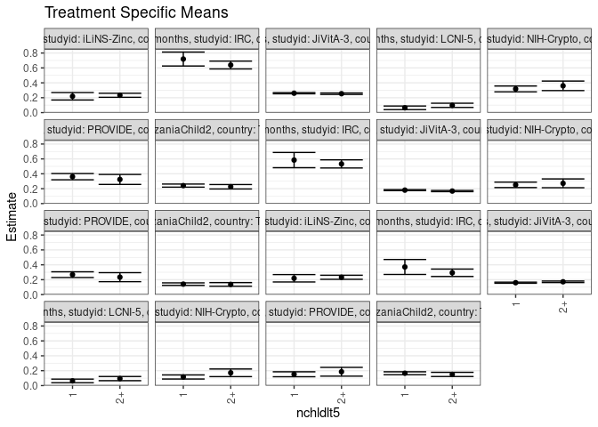

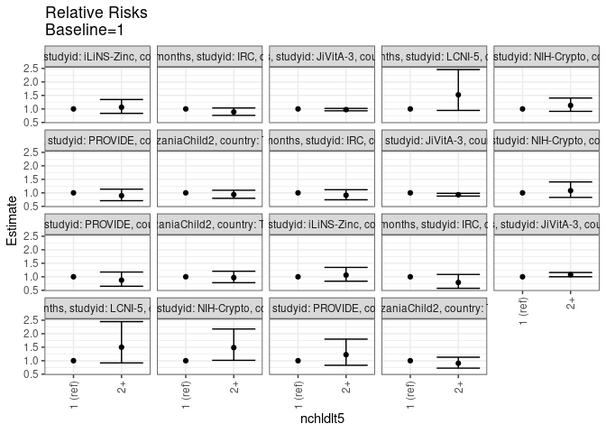

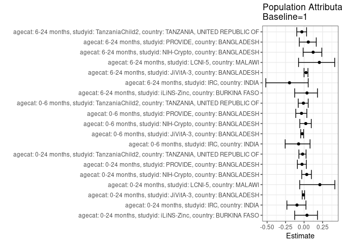

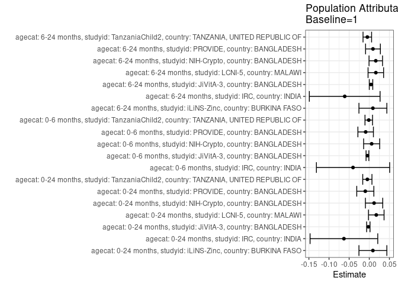

## Results Table

### Parameter: TSM

| agecat | studyid | country | intervention_level | baseline_level | estimate | ci_lower | ci_upper |
| --- | --- | --- | --- | --- | --- | --- | --- |
| 0-24 months | iLiNS-Zinc | BURKINA FASO | 1 | NA | 0.2190121 | 0.1690368 | 0.2689874 |
| 0-24 months | iLiNS-Zinc | BURKINA FASO | 2+ | NA | 0.2325142 | 0.2052238 | 0.2598046 |
| 0-24 months | IRC | INDIA | 1 | NA | 0.7191011 | 0.6256137 | 0.8125886 |
| 0-24 months | IRC | INDIA | 2+ | NA | 0.6386293 | 0.5860122 | 0.6912464 |
| 0-24 months | JiVitA-3 | BANGLADESH | 1 | NA | 0.2603925 | 0.2526614 | 0.2681235 |
| 0-24 months | JiVitA-3 | BANGLADESH | 2+ | NA | 0.2537867 | 0.2438958 | 0.2636776 |
| 0-24 months | LCNI-5 | MALAWI | 1 | NA | 0.0639386 | 0.0396747 | 0.0882025 |
| 0-24 months | LCNI-5 | MALAWI | 2+ | NA | 0.0973872 | 0.0690487 | 0.1257256 |
| 0-24 months | NIH-Crypto | BANGLADESH | 1 | NA | 0.3179298 | 0.2786638 | 0.3571957 |
| 0-24 months | NIH-Crypto | BANGLADESH | 2+ | NA | 0.3594470 | 0.2955619 | 0.4233321 |
| 0-24 months | PROVIDE | BANGLADESH | 1 | NA | 0.3613281 | 0.3196879 | 0.4029684 |
| 0-24 months | PROVIDE | BANGLADESH | 2+ | NA | 0.3244681 | 0.2574968 | 0.3914394 |
| 0-24 months | TanzaniaChild2 | TANZANIA, UNITED REPUBLIC OF | 1 | NA | 0.2412951 | 0.2205638 | 0.2620263 |
| 0-24 months | TanzaniaChild2 | TANZANIA, UNITED REPUBLIC OF | 2+ | NA | 0.2259358 | 0.1959601 | 0.2559115 |
| 0-6 months | IRC | INDIA | 1 | NA | 0.5842697 | 0.4817527 | 0.6867867 |
| 0-6 months | IRC | INDIA | 2+ | NA | 0.5327103 | 0.4780635 | 0.5873571 |
| 0-6 months | JiVitA-3 | BANGLADESH | 1 | NA | 0.1807524 | 0.1739772 | 0.1875276 |
| 0-6 months | JiVitA-3 | BANGLADESH | 2+ | NA | 0.1681635 | 0.1600795 | 0.1762475 |
| 0-6 months | NIH-Crypto | BANGLADESH | 1 | NA | 0.2513863 | 0.2148070 | 0.2879657 |
| 0-6 months | NIH-Crypto | BANGLADESH | 2+ | NA | 0.2718894 | 0.2126515 | 0.3311273 |
| 0-6 months | PROVIDE | BANGLADESH | 1 | NA | 0.2675781 | 0.2292048 | 0.3059515 |
| 0-6 months | PROVIDE | BANGLADESH | 2+ | NA | 0.2340426 | 0.1734765 | 0.2946086 |
| 0-6 months | TanzaniaChild2 | TANZANIA, UNITED REPUBLIC OF | 1 | NA | 0.1405009 | 0.1236634 | 0.1573384 |
| 0-6 months | TanzaniaChild2 | TANZANIA, UNITED REPUBLIC OF | 2+ | NA | 0.1363636 | 0.1117654 | 0.1609618 |
| 6-24 months | iLiNS-Zinc | BURKINA FASO | 1 | NA | 0.2190121 | 0.1690368 | 0.2689874 |
| 6-24 months | iLiNS-Zinc | BURKINA FASO | 2+ | NA | 0.2325142 | 0.2052238 | 0.2598046 |
| 6-24 months | IRC | INDIA | 1 | NA | 0.3707865 | 0.2703147 | 0.4712584 |
| 6-24 months | IRC | INDIA | 2+ | NA | 0.2928349 | 0.2429926 | 0.3426771 |
| 6-24 months | JiVitA-3 | BANGLADESH | 1 | NA | 0.1594966 | 0.1520967 | 0.1668965 |
| 6-24 months | JiVitA-3 | BANGLADESH | 2+ | NA | 0.1718185 | 0.1616477 | 0.1819892 |
| 6-24 months | LCNI-5 | MALAWI | 1 | NA | 0.0625000 | 0.0382741 | 0.0867259 |
| 6-24 months | LCNI-5 | MALAWI | 2+ | NA | 0.0937500 | 0.0657226 | 0.1217774 |
| 6-24 months | NIH-Crypto | BANGLADESH | 1 | NA | 0.1153846 | 0.0879060 | 0.1428633 |
| 6-24 months | NIH-Crypto | BANGLADESH | 2+ | NA | 0.1714286 | 0.1204201 | 0.2224371 |
| 6-24 months | PROVIDE | BANGLADESH | 1 | NA | 0.1517857 | 0.1185327 | 0.1850387 |
| 6-24 months | PROVIDE | BANGLADESH | 2+ | NA | 0.1856287 | 0.1266118 | 0.2446457 |
| 6-24 months | TanzaniaChild2 | TANZANIA, UNITED REPUBLIC OF | 1 | NA | 0.1655821 | 0.1459871 | 0.1851770 |
| 6-24 months | TanzaniaChild2 | TANZANIA, UNITED REPUBLIC OF | 2+ | NA | 0.1499203 | 0.1219702 | 0.1778703 |

### Parameter: E(Y)

| agecat | studyid | country | intervention_level | baseline_level | estimate | ci_lower | ci_upper |
| --- | --- | --- | --- | --- | --- | --- | --- |
| 0-24 months | iLiNS-Zinc | BURKINA FASO | NA | NA | 0.2279712 | 0.2010014 | 0.2549409 |
| 0-24 months | IRC | INDIA | NA | NA | 0.6560976 | 0.6100625 | 0.7021326 |
| 0-24 months | JiVitA-3 | BANGLADESH | NA | NA | 0.2580118 | 0.2515422 | 0.2644814 |
| 0-24 months | LCNI-5 | MALAWI | NA | NA | 0.0812808 | 0.0624736 | 0.1000879 |
| 0-24 months | NIH-Crypto | BANGLADESH | NA | NA | 0.3298153 | 0.2963239 | 0.3633067 |
| 0-24 months | PROVIDE | BANGLADESH | NA | NA | 0.3514286 | 0.3160364 | 0.3868207 |
| 0-24 months | TanzaniaChild2 | TANZANIA, UNITED REPUBLIC OF | NA | NA | 0.2364780 | 0.2194210 | 0.2535349 |
| 0-6 months | IRC | INDIA | NA | NA | 0.5439024 | 0.4956326 | 0.5921723 |
| 0-6 months | JiVitA-3 | BANGLADESH | NA | NA | 0.1762075 | 0.1705779 | 0.1818372 |
| 0-6 months | NIH-Crypto | BANGLADESH | NA | NA | 0.2572559 | 0.2261171 | 0.2883948 |
| 0-6 months | PROVIDE | BANGLADESH | NA | NA | 0.2585714 | 0.2261125 | 0.2910304 |
| 0-6 months | TanzaniaChild2 | TANZANIA, UNITED REPUBLIC OF | NA | NA | 0.1392034 | 0.1253080 | 0.1530987 |
| 6-24 months | iLiNS-Zinc | BURKINA FASO | NA | NA | 0.2279712 | 0.2010014 | 0.2549409 |
| 6-24 months | IRC | INDIA | NA | NA | 0.3097561 | 0.2649438 | 0.3545684 |
| 6-24 months | JiVitA-3 | BANGLADESH | NA | NA | 0.1638320 | 0.1577093 | 0.1699547 |
| 6-24 months | LCNI-5 | MALAWI | NA | NA | 0.0787500 | 0.0600738 | 0.0974262 |
| 6-24 months | NIH-Crypto | BANGLADESH | NA | NA | 0.1315068 | 0.1069744 | 0.1560393 |
| 6-24 months | PROVIDE | BANGLADESH | NA | NA | 0.1609756 | 0.1319065 | 0.1900447 |
| 6-24 months | TanzaniaChild2 | TANZANIA, UNITED REPUBLIC OF | NA | NA | 0.1606965 | 0.1446374 | 0.1767556 |

### Parameter: RR

| agecat | studyid | country | intervention_level | baseline_level | estimate | ci_lower | ci_upper |
| --- | --- | --- | --- | --- | --- | --- | --- |
| 0-24 months | iLiNS-Zinc | BURKINA FASO | 1 | 1 | 1.0000000 | 1.0000000 | 1.0000000 |
| 0-24 months | iLiNS-Zinc | BURKINA FASO | 2+ | 1 | 1.0616498 | 0.8361137 | 1.3480229 |
| 0-24 months | IRC | INDIA | 1 | 1 | 1.0000000 | 1.0000000 | 1.0000000 |
| 0-24 months | IRC | INDIA | 2+ | 1 | 0.8880938 | 0.7614028 | 1.0358652 |
| 0-24 months | JiVitA-3 | BANGLADESH | 1 | 1 | 1.0000000 | 1.0000000 | 1.0000000 |
| 0-24 months | JiVitA-3 | BANGLADESH | 2+ | 1 | 0.9746315 | 0.9310654 | 1.0202362 |
| 0-24 months | LCNI-5 | MALAWI | 1 | 1 | 1.0000000 | 1.0000000 | 1.0000000 |
| 0-24 months | LCNI-5 | MALAWI | 2+ | 1 | 1.5231354 | 0.9441795 | 2.4570979 |
| 0-24 months | NIH-Crypto | BANGLADESH | 1 | 1 | 1.0000000 | 1.0000000 | 1.0000000 |
| 0-24 months | NIH-Crypto | BANGLADESH | 2+ | 1 | 1.1305862 | 0.9105613 | 1.4037772 |
| 0-24 months | PROVIDE | BANGLADESH | 1 | 1 | 1.0000000 | 1.0000000 | 1.0000000 |
| 0-24 months | PROVIDE | BANGLADESH | 2+ | 1 | 0.8979873 | 0.7089323 | 1.1374589 |
| 0-24 months | TanzaniaChild2 | TANZANIA, UNITED REPUBLIC OF | 1 | 1 | 1.0000000 | 1.0000000 | 1.0000000 |
| 0-24 months | TanzaniaChild2 | TANZANIA, UNITED REPUBLIC OF | 2+ | 1 | 0.9363467 | 0.7994490 | 1.0966868 |
| 0-6 months | IRC | INDIA | 1 | 1 | 1.0000000 | 1.0000000 | 1.0000000 |
| 0-6 months | IRC | INDIA | 2+ | 1 | 0.9117541 | 0.7440600 | 1.1172427 |
| 0-6 months | JiVitA-3 | BANGLADESH | 1 | 1 | 1.0000000 | 1.0000000 | 1.0000000 |
| 0-6 months | JiVitA-3 | BANGLADESH | 2+ | 1 | 0.9303529 | 0.8801147 | 0.9834587 |
| 0-6 months | NIH-Crypto | BANGLADESH | 1 | 1 | 1.0000000 | 1.0000000 | 1.0000000 |
| 0-6 months | NIH-Crypto | BANGLADESH | 2+ | 1 | 1.0815600 | 0.8322743 | 1.4055128 |
| 0-6 months | PROVIDE | BANGLADESH | 1 | 1 | 1.0000000 | 1.0000000 | 1.0000000 |
| 0-6 months | PROVIDE | BANGLADESH | 2+ | 1 | 0.8746700 | 0.6506580 | 1.1758060 |
| 0-6 months | TanzaniaChild2 | TANZANIA, UNITED REPUBLIC OF | 1 | 1 | 1.0000000 | 1.0000000 | 1.0000000 |
| 0-6 months | TanzaniaChild2 | TANZANIA, UNITED REPUBLIC OF | 2+ | 1 | 0.9705534 | 0.7815668 | 1.2052378 |
| 6-24 months | iLiNS-Zinc | BURKINA FASO | 1 | 1 | 1.0000000 | 1.0000000 | 1.0000000 |
| 6-24 months | iLiNS-Zinc | BURKINA FASO | 2+ | 1 | 1.0616498 | 0.8361137 | 1.3480229 |
| 6-24 months | IRC | INDIA | 1 | 1 | 1.0000000 | 1.0000000 | 1.0000000 |
| 6-24 months | IRC | INDIA | 2+ | 1 | 0.7897668 | 0.5734933 | 1.0876006 |
| 6-24 months | JiVitA-3 | BANGLADESH | 1 | 1 | 1.0000000 | 1.0000000 | 1.0000000 |
| 6-24 months | JiVitA-3 | BANGLADESH | 2+ | 1 | 1.0772548 | 1.0008858 | 1.1594508 |
| 6-24 months | LCNI-5 | MALAWI | 1 | 1 | 1.0000000 | 1.0000000 | 1.0000000 |
| 6-24 months | LCNI-5 | MALAWI | 2+ | 1 | 1.5000000 | 0.9193889 | 2.4472777 |
| 6-24 months | NIH-Crypto | BANGLADESH | 1 | 1 | 1.0000000 | 1.0000000 | 1.0000000 |
| 6-24 months | NIH-Crypto | BANGLADESH | 2+ | 1 | 1.4857143 | 1.0148881 | 2.1749658 |
| 6-24 months | PROVIDE | BANGLADESH | 1 | 1 | 1.0000000 | 1.0000000 | 1.0000000 |
| 6-24 months | PROVIDE | BANGLADESH | 2+ | 1 | 1.2229658 | 0.8312510 | 1.7992705 |
| 6-24 months | TanzaniaChild2 | TANZANIA, UNITED REPUBLIC OF | 1 | 1 | 1.0000000 | 1.0000000 | 1.0000000 |
| 6-24 months | TanzaniaChild2 | TANZANIA, UNITED REPUBLIC OF | 2+ | 1 | 0.9054136 | 0.7260159 | 1.1291402 |

### Parameter: PAR

| agecat | studyid | country | intervention_level | baseline_level | estimate | ci_lower | ci_upper |
| --- | --- | --- | --- | --- | --- | --- | --- |
| 0-24 months | iLiNS-Zinc | BURKINA FASO | 1 | NA | 0.0089590 | -0.0256958 | 0.0436139 |
| 0-24 months | IRC | INDIA | 1 | NA | -0.0630036 | -0.1470555 | 0.0210484 |
| 0-24 months | JiVitA-3 | BANGLADESH | 1 | NA | -0.0023807 | -0.0066025 | 0.0018412 |
| 0-24 months | LCNI-5 | MALAWI | 1 | NA | 0.0173422 | -0.0020346 | 0.0367190 |
| 0-24 months | NIH-Crypto | BANGLADESH | 1 | NA | 0.0118855 | -0.0096234 | 0.0333945 |
| 0-24 months | PROVIDE | BANGLADESH | 1 | NA | -0.0098996 | -0.0311140 | 0.0113149 |
| 0-24 months | TanzaniaChild2 | TANZANIA, UNITED REPUBLIC OF | 1 | NA | -0.0048171 | -0.0162512 | 0.0066170 |
| 0-6 months | IRC | INDIA | 1 | NA | -0.0403672 | -0.1313450 | 0.0506105 |
| 0-6 months | JiVitA-3 | BANGLADESH | 1 | NA | -0.0045449 | -0.0080083 | -0.0010814 |
| 0-6 months | NIH-Crypto | BANGLADESH | 1 | NA | 0.0058696 | -0.0140726 | 0.0258118 |
| 0-6 months | PROVIDE | BANGLADESH | 1 | NA | -0.0090067 | -0.0282945 | 0.0102811 |
| 0-6 months | TanzaniaChild2 | TANZANIA, UNITED REPUBLIC OF | 1 | NA | -0.0012976 | -0.0106468 | 0.0080516 |
| 6-24 months | iLiNS-Zinc | BURKINA FASO | 1 | NA | 0.0089590 | -0.0256958 | 0.0436139 |
| 6-24 months | IRC | INDIA | 1 | NA | -0.0610304 | -0.1488951 | 0.0268343 |
| 6-24 months | JiVitA-3 | BANGLADESH | 1 | NA | 0.0043354 | 0.0000076 | 0.0086631 |
| 6-24 months | LCNI-5 | MALAWI | 1 | NA | 0.0162500 | -0.0030445 | 0.0355445 |
| 6-24 months | NIH-Crypto | BANGLADESH | 1 | NA | 0.0161222 | -0.0006466 | 0.0328911 |
| 6-24 months | PROVIDE | BANGLADESH | 1 | NA | 0.0091899 | -0.0092432 | 0.0276229 |
| 6-24 months | TanzaniaChild2 | TANZANIA, UNITED REPUBLIC OF | 1 | NA | -0.0048856 | -0.0155382 | 0.0057671 |

### Parameter: PAF

| agecat | studyid | country | intervention_level | baseline_level | estimate | ci_lower | ci_upper |
| --- | --- | --- | --- | --- | --- | --- | --- |
| 0-24 months | iLiNS-Zinc | BURKINA FASO | 1 | NA | 0.0392990 | -0.1271369 | 0.1811585 |
| 0-24 months | IRC | INDIA | 1 | NA | -0.0960277 | -0.2325565 | 0.0253779 |
| 0-24 months | JiVitA-3 | BANGLADESH | 1 | NA | -0.0092270 | -0.0257246 | 0.0070053 |
| 0-24 months | LCNI-5 | MALAWI | 1 | NA | 0.2133612 | -0.0591012 | 0.4157305 |
| 0-24 months | NIH-Crypto | BANGLADESH | 1 | NA | 0.0360370 | -0.0314293 | 0.0990902 |
| 0-24 months | PROVIDE | BANGLADESH | 1 | NA | -0.0281695 | -0.0903511 | 0.0304660 |
| 0-24 months | TanzaniaChild2 | TANZANIA, UNITED REPUBLIC OF | 1 | NA | -0.0203700 | -0.0698770 | 0.0268460 |
| 0-6 months | IRC | INDIA | 1 | NA | -0.0742178 | -0.2554488 | 0.0808515 |
| 0-6 months | JiVitA-3 | BANGLADESH | 1 | NA | -0.0257928 | -0.0456077 | -0.0063534 |
| 0-6 months | NIH-Crypto | BANGLADESH | 1 | NA | 0.0228162 | -0.0578432 | 0.0973255 |
| 0-6 months | PROVIDE | BANGLADESH | 1 | NA | -0.0348325 | -0.1121423 | 0.0371031 |
| 0-6 months | TanzaniaChild2 | TANZANIA, UNITED REPUBLIC OF | 1 | NA | -0.0093213 | -0.0787638 | 0.0556509 |
| 6-24 months | iLiNS-Zinc | BURKINA FASO | 1 | NA | 0.0392990 | -0.1271369 | 0.1811585 |
| 6-24 months | IRC | INDIA | 1 | NA | -0.1970273 | -0.5172488 | 0.0556101 |
| 6-24 months | JiVitA-3 | BANGLADESH | 1 | NA | 0.0264624 | -0.0003060 | 0.0525146 |
| 6-24 months | LCNI-5 | MALAWI | 1 | NA | 0.2063492 | -0.0749032 | 0.4140109 |
| 6-24 months | NIH-Crypto | BANGLADESH | 1 | NA | 0.1225962 | -0.0128980 | 0.2399654 |
| 6-24 months | PROVIDE | BANGLADESH | 1 | NA | 0.0570887 | -0.0643280 | 0.1646545 |
| 6-24 months | TanzaniaChild2 | TANZANIA, UNITED REPUBLIC OF | 1 | NA | -0.0304023 | -0.0988268 | 0.0337613 |